# Baseball Player Statistics and Salary Earnings

## Eric Gordon

An analysis on Sean Lahman's baseball database.

## Intro

What statistics are most important in baseball? Which players get paid more? How much money will the average baseball player make in the future?There are countless questions worth examining, however there is one question that I will dive deeper into in this analysis.

Are there particular statistics in baseball that correlate to some professionals earning more money than others?

In the following work, you will see analysis attempting to awnser this question. By taking a look at baseball players and their career statistics, I hope to determine what statistics are more likely to correlate to high earning athletes. To do this, we will import the collective stats of baseball players from 1871, and examine the career earnings of these players, and will run correlation calculations to examine which statistics are most likely to eplain higher earnings.

```python
#Import Python Modules
#Defining import function

import numpy as np
import pandas as pd
import matplotlib.pyplot as plt
import seaborn as sns


def import_stats(batting_csv,pitching_csv,players_csv):
    players= pd.read_csv(players_csv,\
                    usecols=['playerID','nameLast','nameGiven',\
                             'debut',"finalGame"]).copy()     # .copy to make sure we do not change original.
    batting= pd.read_csv(batting_csv).copy()
    batting.drop(['yearID','stint','teamID','lgID'],1,inplace=True)                                # Drop some less important stats.
    pitching=pd.read_csv(pitching_csv).copy()
    pitching.drop(['yearID','IBB','GF','stint','teamID','lgID','SH','SF','GIDP'],1,inplace=True)   # Drop some less important stats.
    pitching_avg=pitching[['ERA','BAOpp','playerID']].groupby('playerID',as_index=False).mean()    # average stats needed
    pitching.drop(['ERA','BAOpp'],1,inplace=True)                                                  #Get rid of these from DF
    pitching_sums=pitching.groupby('playerID',as_index=False).sum()
    pitching_totals=pitching_sums.merge(pitching_avg,on='playerID',how='inner')                    # Pitching stats summed or averaged
    batting_sums=batting.groupby('playerID',as_index=False).sum()                                  #All batting stats summed
    pitching_stats = players.merge(pitching_totals, on='playerID',how='inner')                     #Merge players with stats
    batting_stats =players.merge(batting_sums, on='playerID',how='inner')
    return (batting_stats, pitching_stats)
```

The function above was defined to give us a worakable Pandas Dataframe for our batting and pitching statistics. Since we are investigating the player's career stats with their career salary earnings, we will use the above function to import the statistics and create two seaperate Dataframes, one for pitchers and the other for batters. These players were seaperated because of the nature of the game of baseball, and the complete lack of overlap between bating and pitching statistics. What the function will do, is import the CSV files found from our source, and create dataframes of the players' personal info as well as the batting or pitching performance statistics. The stats we will compare for this analysis will be the following:

###### Batting:

Games, At Bats, Runs, Hits, Doubles, Triples, Home Runs, Runs Batted In, Stolen Bases, Caught Stealing, Walks, Strike Outs, Intentional Walks, Hit By Pitch, Sacrafice Hits, Sacrafice Flies, Grounded Into Double Plays

###### Pitching:

Wins, Losses, Games, Games Statred, Complete Games, Shut Outs, Saves, Outs Pitched, Hits Allowed, Earned Runs Allowed, Home Runs Allowed, Walks, Strike Outs, Wild Pitches, Hit By Pitches Thrown, Balks, Batters Faced, Runs Given Up, Earned Run Average, Opponents Batting Average

We need to make sure to include not just the statistics of each player, but also the salary for each player. The code below imports all of the playing statistics, then merges the salary information for eachplayer into a new column. For this column, we will combine all salary earning for an individual player into one data point named "SumSalary" that will represent the career earnings for each player. Thus the final dataframes will have hall playing statistics as well as a career salary datapoint.

The output at the bottom is a reference of how many players are in each Dataframe.

```python
#Importing the Data

batting_stats, pitching_stats = import_stats('/Users/ericgordo/Documents/Udacity/P2 Intro to Data Analysis/P2 Baseball Project/github_P2/Batting.csv',\
                                             '/Users/ericgordo/Documents/Udacity/P2 Intro to Data Analysis/P2 Baseball Project/github_P2/Pitching.csv',\
                                             '/Users/ericgordo/Documents/Udacity/P2 Intro to Data Analysis/P2 Baseball Project/github_P2/Master.csv')

salaries= pd.read_csv('/Users/ericgordo/Documents/Udacity/P2 Intro to Data Analysis/P2 Baseball Project/github_P2/Salaries.csv',\
                      usecols=['playerID','teamID','salary','yearID'])

sum_salary=salaries.groupby('playerID',as_index=False).sum()              # Turn Salaries into career Summed Salaries!!!
sum_salary.rename(columns = {'salary': 'SumSalary'},inplace=True)
sum_salary.drop(['yearID'],1,inplace=True)

pitchers_and_salaries =pitching_stats.merge(sum_salary, on='playerID',how='inner')
batters_and_salaries=batting_stats.merge(sum_salary,on='playerID',how='inner')

pitchers_and_salaries.dropna(inplace=True)
batters_and_salaries.dropna(inplace=True)

print "Pitchers:",len(pitchers_and_salaries)
print "Batters:",len(batters_and_salaries)
```

```
Pitchers: 2690
Batters: 4822
```

Now that all of the information is imported, let's take a deeper look at our data.

## Exploring Salaries

Before delving into the relationship between stats and salary earnings. Let's take a look at the distribution of salaries on their own, and some stats regarding the range of the player salaries.

```
Salary Stats
          SumSalary
count  4.963000e+03
mean   1.035039e+07
std    2.321268e+07
min    6.000000e+04
25%    4.824000e+05
50%    1.520200e+06
75%    8.652125e+06
max    3.774163e+08
```

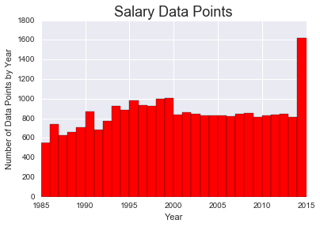

```python
%pylab inline
plt.figure(1)
x=salaries["yearID"].values
plt.hist(x,bins=30,range=(1985,2015),histtype='barstacked',color="red")
plt.xlabel('Year')
plt.ylabel('Number of Data Points by Year')
plt.title('Salary Data Points',fontsize=18)
print"\n"
print "Salary Stats"
print sum_salary.describe()
```

## Correlation Function and Exploration

Now that we have seen information about salaries and the data, we want to investigate which baseball stats have the highest relationship with players' career earnings. The function below will be used multiple times to compare the correlation between the total salary for a player, and each other stat. We will be using Pearson's Correlation for all correlation calculations.

```python
def find_corr(df,stat):
    corr= df.corr()[stat].sort_values(ascending=False)
    corr=corr.iloc[1:5],corr.tail(5)
    return corr
```

```python
print "Pitching Correlations"
print find_corr(pitchers_and_salaries,'SumSalary')
print ('\n')
print "Batting Correlations"
print find_corr(batters_and_salaries,'SumSalary')
```

```
Pitching Correlations
(SO     0.680517
W      0.630160
HBP    0.628581
HR     0.598063
Name: SumSalary, dtype: float64, BK       0.283302
SV       0.256587
CG       0.248042
BAOpp   -0.078824
ERA     -0.114136
Name: SumSalary, dtype: float64)


Batting Correlations
(HR     0.566856
RBI    0.538257
R      0.523263
SO     0.521276
Name: SumSalary, dtype: float64, IBB    0.468294
3B     0.324479
SB     0.303486
CS     0.291735
SH     0.253299
Name: SumSalary, dtype: float64)
```

After running this for the first time we can see a couple of things.

For pitchers, it seems that the cumliative stats, like "Strikeouts", and "Wins" have the highest correlation to career earnings. The more strikeouts and wins a player accumilates over a career, the higher their career earnings will most likely be. The correlation coefficient for strikeouts has a value of r=.680, which is a fairly strong correlation.

For batters, "Home Runs" are the most telling stat of correlation to a players' career earnings, with "Runs Batted In" a close second. Also, "Sacrafice Hits" and "Caught Steeling" stats are the least predictive of career earnings, which I believe makes sense, because these stats are often not seen as crucial stats for judging a player's skills. This correlation coefficent calculated for the number of Home Runs a player hits over his career and his salary earnings was calculated to be r=.566.

# Further Questions

So Home Runs and Strikeouts are the most crucial statstics for baseball players who want to earn more money! Obviously with fans so excited to see pitchers who strike opponents out and batters who can hit the long ball, it seems to make sense that players who earn more have more strikeouts or home runs! There are some more questions worth addressing though before we can be convinced of the importance of these two stats.

One thing that stuck out in this first analysis is that cummlitative stats have a higher relationfhip to player's career earnings than other factors. Even when looking at negative stats like the "home runs against" a pitcher, the more home runs a pitcher had given up, the higher that player's career earnings. The fact that this stat has the fourth highest correlation to pitchers' salaries made me realize this was worth investigating.

Because we are comparing TOTAL career earnings to other stats, players who play longer are more likely to gain all additive stats (wins, loses, home runs against, ect.). Since this could possibly be a baised stat, let's investigate the relationship between Annual Average Salary and the rest of a player's statistics. This could possibly give us different correlation calculations. Thus we will adjust this and recheck the analysis.

Additionaly, I was surprised not to see batting Batting Average as a statistic in the online database; argueably the most refered to stat in baseball for hitters. Thus I also want to calculate this statistic by hand, to see if there is a high correlation between Batting Averages and career earnings. I believe batting averages may be more correlated to palyers earning money than Home Runs. Batting average is a simple calculation of taking the total number of hits a player has, and dividng that number by the total number of at bats. The code below will calculate batting averages and add it to our dataframe.

```python
#Switch to Average Salaries! Should help with ERA?  Take another Comparison
#Also Add BA, because that is my favorite known stat

avg_salary=salaries.groupby('playerID',as_index=False).mean()              # CREATE DF with AVERAGE SALARY, Drop Sum
avg_salary.rename(columns = {'salary': 'AvgSalary'},inplace=True)


pitchers_avg=pitching_stats.merge(avg_salary, on='playerID',how='inner')
batters_avg=batting_stats.merge(avg_salary, on='playerID',how='inner')

batters_avg['BA']=batters_avg['H']/batters_avg['AB']                     #Add BA  to batting stats

print "Batters:",len(batters_avg)
print "Pitchers:",len(pitchers_avg)
```

[output not shown]

Now having average salaries instead of summed salaries, we will run the correlation function again to see if we notice anything different.

```python
# Do correlations change compared to original calculations?

print "Pitching Correlations"
print find_corr(pitchers_avg,'AvgSalary')
print ('\n')
print "Batting Correlations"
print find_corr(batters_avg,'AvgSalary')
```

```
Pitching Correlations
(SO     0.601882
HBP    0.554078
W      0.543057
HR     0.524443
Name: AvgSalary, dtype: float64, SV       0.216138
BK       0.215162
CG       0.188707
BAOpp   -0.069994
ERA     -0.131338
Name: AvgSalary, dtype: float64)


Batting Correlations
(HR     0.493783
SO     0.474159
RBI    0.468956
2B     0.460415
Name: AvgSalary, dtype: float64, SB        0.256838
yearID    0.245080
CS        0.243915
SH        0.217920
BA        0.096982
Name: AvgSalary, dtype: float64)
```

Interestingly, one stat for each batters and pitchers became more important in describing the correlation between performance and salary earnings. That is for pitchers, the number of players they "Hit with Pitches" became a stronger indicator of average salary earnings than Wins, and for Batters, "Strike Outs" became more predicitve then runs batted in. This is worth noting, but clearly the stats that are still most correlated to a player's earnings are Home Runs and Strike Outs.

I was shocked to see how little of a correlation there was between batting average and a player's earnings. I hope to see why there is such a small correlation between this stat and salries better visually on a scatterplot.

# Visual Examination

To examine further, scatterplots may visually help us see some trends. We will look at the pitchers and batters seaperately, and will also investigate the lack of correlation between a batting average and a player's salary, before concluding whether home runs is the most important stat for players.

# Strike Outs vs. Salaries

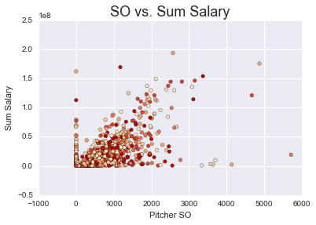

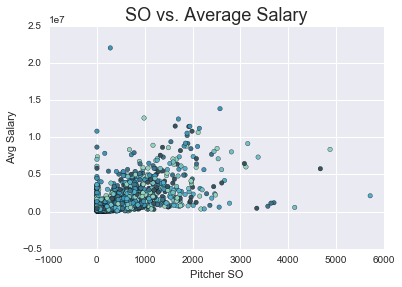

```python
%pylab inline

color1=sns.color_palette("OrRd")
color2=sns.color_palette("GnBu_d")

plt.figure(1)
#plt.subplot(2,1,1)
plt.scatter(pitchers_and_salaries['SO'],pitchers_and_salaries['SumSalary'],c=color1)
plt.xlabel('Pitcher SO')
plt.ylabel('Sum Salary')
plt.title('SO vs. Sum Salary',fontsize=18)

plt.figure(2)
plt.scatter(pitchers_avg['SO'],pitchers_avg['AvgSalary'],c=color2)
plt.xlabel('Pitcher SO')
plt.ylabel('Avg Salary')
plt.title('SO vs. Average Salary',fontsize=18)
```

# Home Runs vs Total Salary

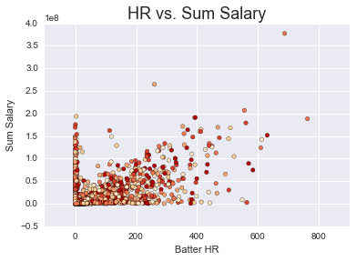

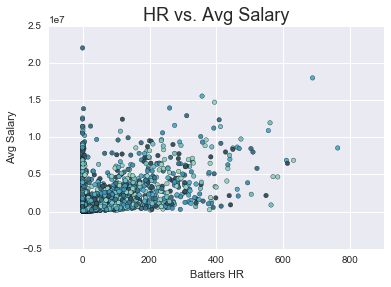

```python
plt.figure(1)
plt.scatter(batters_and_salaries['HR'],batters_and_salaries['SumSalary'],c=color1)
plt.xlabel('Batter HR')
plt.ylabel('Sum Salary')
plt.title('HR vs. Sum Salary',fontsize=18)
plt.figure(2)
plt.scatter(batters_avg['HR'],batters_avg['AvgSalary'],c=color2)
plt.xlabel('Batters HR')
plt.ylabel('Avg Salary')
plt.title('HR vs. Avg Salary',fontsize=18)
```

### NOTE

Before Moving on with this analysis, it is clear that there is a large sample of data right on the y-axis for both of these home run scatterplots, representing individuals who have hit few or no home runs. This does not seem like a fair representation. A lot of these players could be players with just one, or a few at bats. Also quite possibly this data could include pitchers. Thuse we are going to limit this new sample to players who have had enough career at bats. We will cut out anyone who has had less than a 100 at bats from this sample. We will also rerun the correlations to see if this changes any of the numbers.

```
Number of Players Left
2716
2716


Batting Correlations Total Salary
(HR     0.571302
RBI    0.538667
SO     0.522873
R      0.521040
Name: SumSalary, dtype: float64, SF    0.456101
3B    0.282013
SB    0.271107
CS    0.245832
SH    0.188545
Name: SumSalary, dtype: float64)


Batting Correlations Avg Salary
(HR     0.512785
SO     0.490382
RBI    0.480949
2B     0.470445
Name: AvgSalary, dtype: float64, 3B    0.254583
SB    0.231322
CS    0.202305
SH    0.155880
BA    0.044160
Name: AvgSalary, dtype: float64)
```

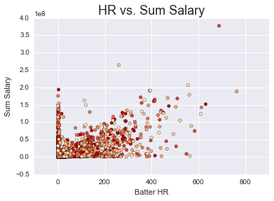

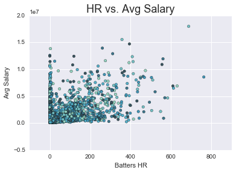

```python
#GET rid of players with few at bats
batters_and_salaries= batters_and_salaries[batters_and_salaries['AB'] > 99]
batters_avg= batters_avg[batters_avg['AB'] > 99]
print "Number of Players Left"
print len(batters_and_salaries)
print len(batters_avg)
print "\n"
plt.figure(1)
plt.scatter(batters_and_salaries['HR'],batters_and_salaries['SumSalary'],c=color1)
plt.xlabel('Batter HR')
plt.ylabel('Sum Salary')
plt.title('HR vs. Sum Salary', fontsize=18)
print "Batting Correlations Total Salary"
print find_corr(batters_and_salaries,'SumSalary')
print "\n"
plt.figure(2)
plt.scatter(batters_avg['HR'],batters_avg['AvgSalary'],c=color2)
plt.xlabel('Batters HR')
plt.ylabel('Avg Salary')
plt.title('HR vs. Avg Salary',fontsize=18)
print "Batting Correlations Avg Salary"
print find_corr(batters_avg,'AvgSalary')
```

## Batting Average Investigation

Finally, it is worth investigating why batting averages have such a low correlation with salary earnings. Even after cutting the players who have had less then 100 at bats it still is calculated as the weakest of all the correlation coefficients. Let's look at the scatterplots below to try to investigate.

```python
color=sns.color_palette("Blues")
plt.scatter(batters_avg['BA'],batters_avg['AvgSalary'],c=color)

plt.xlabel('Batting Average')
plt.ylabel('Avg Salary')
plt.title('BA vs. Average Salary',fontsize=18)
```

[output not shown]

[output not shown]

```
(HR     0.651435
RBI    0.629714
2B     0.627458
SO     0.624875
Name: AvgSalary, dtype: float64, 3B        0.346346
SB        0.301098
CS        0.281201
yearID    0.269800
SH        0.061145
Name: AvgSalary, dtype: float64)
```

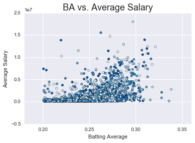

```python
batters_avg= batters_avg[batters_avg['BA'] > 0.200]

plt.scatter(batters_avg['BA'],batters_avg['AvgSalary'],c=color)

plt.xlabel('Batting Average')
plt.ylabel('Average Salary')
plt.title('BA vs. Average Salary',fontsize=18)


print find_corr(batters_avg,'AvgSalary')
```

Now this scatterplot seems to have a slight correlation trend. This scatterplot visually seems to make a lot more sense. Also from looking at the calculation above, the correlation is now stronger, and is no longer one of the bottom 4 values in our calculations.

This scatterplot I feel is a great final representation of players' batting averages compared to their expected career average salary earnings. While Batting Avearage is still not as predictive of a stat for a palyer's earnings as Home Runs or a few other statistics, it still is valued in the baseball community as a very important statistic.

# Conclusions and Suggestions

If you are a baseball player, and you want to earn more in your career, it clearly seems that it is more likely to happen if you hit home runs as a batter, or throw strike outs as a pitcher. These stats seem to be the most correlated to higher career earnings than others like games played or even games won. While these stats are the most correlated to palyers' career salaries, there is still much room for further investigation.

This simply summed career salaries, so it may be worth examining players's salaries on a normalized scale, or with some other factors into player salary. The statistics in this paper come from players all the way from 1871, but this paper did not account for ecconomic factors like inflation. There may be different results if the salary scales were normalized, or factored with the value of a salary for the time. Also this analysis did not take a look into the social changes in players' contracts over the long history of baseball. So while there was an investigation of how player stats are correlated to career earnings, futuer analysis may look into researching how contracts, salaries, and inflation have affected baseball players earnings.

# Resources

Baseball statistics found and used from: http://www.seanlahman.com/baseball-archive/statistics/

General Troubleshooting: https://www.udacity.com/course/intro-to-data-analysis--ud170